# 基于机器学习与深度学习的乳腺癌良恶性分类研究

## 五、模型综合比较

完成六种模型训练后，需要从多个维度对模型性能进行系统比较。 本节将综合分析分类性能、训练效率以及模型复杂度等方面差异。

```python
result_df = pd.DataFrame(
    results,
    columns=["Model", "Accuracy", "Precision", "Recall", "F1", "ROC-AUC", "Train Time"]
)
result_df
```

|  | Model | Accuracy | Precision | Recall | F1 | ROC-AUC | Train Time |
| --- | --- | --- | --- | --- | --- | --- | --- |
| 0 | Baseline MLP | 0.991228 | 1.000000 | 0.976190 | 0.987952 | 0.997354 | 0.348774 |
| 1 | RBF Network | 0.973684 | 1.000000 | 0.928571 | 0.962963 | 0.997024 | 1.306316 |
| 2 | GA Optimized MLP | 0.964912 | 1.000000 | 0.904762 | 0.950000 | 0.994709 | 0.111429 |
| 3 | Residual Network | 0.964912 | 0.952381 | 0.952381 | 0.952381 | 0.991402 | 0.214229 |
| 4 | Transformer | 0.885965 | 0.853659 | 0.833333 | 0.843373 | 0.961640 | 3.648929 |
| 5 | AutoEncoder+Classifier | 0.947368 | 0.950000 | 0.904762 | 0.926829 | 0.996362 | 0.129352 |

```python
result_df.sort_values("Accuracy", ascending=False)
```

|  | Model | Accuracy | Precision | Recall | F1 | ROC-AUC | Train Time |
| --- | --- | --- | --- | --- | --- | --- | --- |
| 0 | Baseline MLP | 0.991228 | 1.000000 | 0.976190 | 0.987952 | 0.997354 | 0.348774 |
| 1 | RBF Network | 0.973684 | 1.000000 | 0.928571 | 0.962963 | 0.997024 | 1.306316 |
| 2 | GA Optimized MLP | 0.964912 | 1.000000 | 0.904762 | 0.950000 | 0.994709 | 0.111429 |
| 3 | Residual Network | 0.964912 | 0.952381 | 0.952381 | 0.952381 | 0.991402 | 0.214229 |
| 5 | AutoEncoder+Classifier | 0.947368 | 0.950000 | 0.904762 | 0.926829 | 0.996362 | 0.129352 |
| 4 | Transformer | 0.885965 | 0.853659 | 0.833333 | 0.843373 | 0.961640 | 3.648929 |

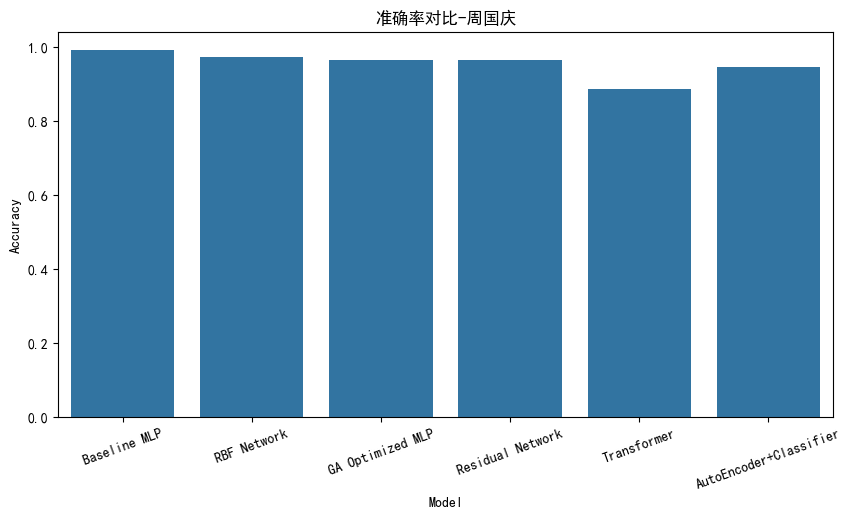

```python
plt.figure(figsize=(10,5))
sns.barplot(data=result_df, x="Model", y="Accuracy")
plt.xticks(rotation=20)
plt.title("准确率对比-周国庆")
plt.show()
```

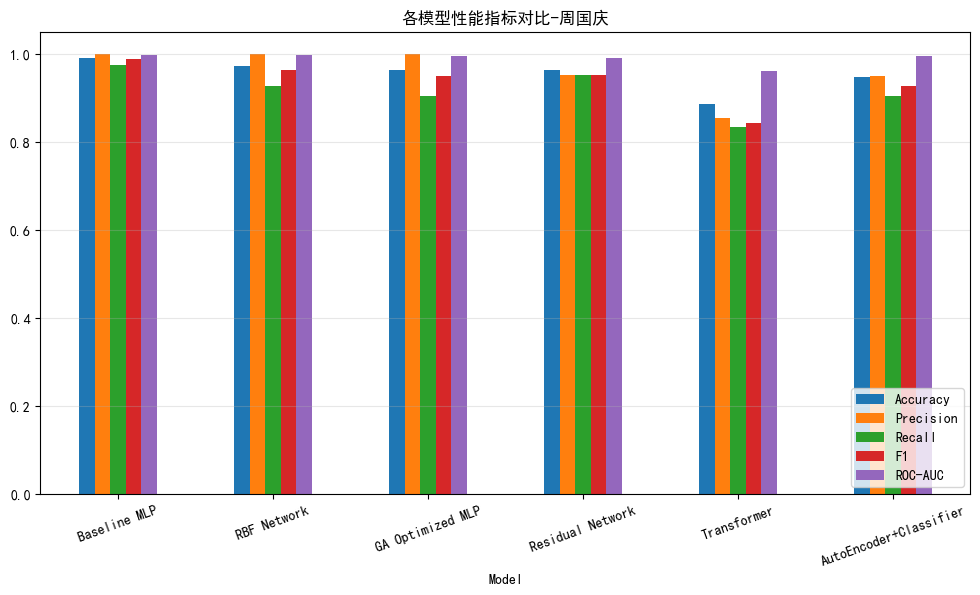

```python
metrics = ["Accuracy", "Precision", "Recall", "F1", "ROC-AUC"]
result_df.set_index("Model")[metrics].plot(kind='bar', figsize=(12,6))
plt.title("各模型性能指标对比-周国庆")
plt.xticks(rotation=20)
plt.legend(loc='lower right')
plt.grid(axis='y', alpha=0.3)
plt.show()
```

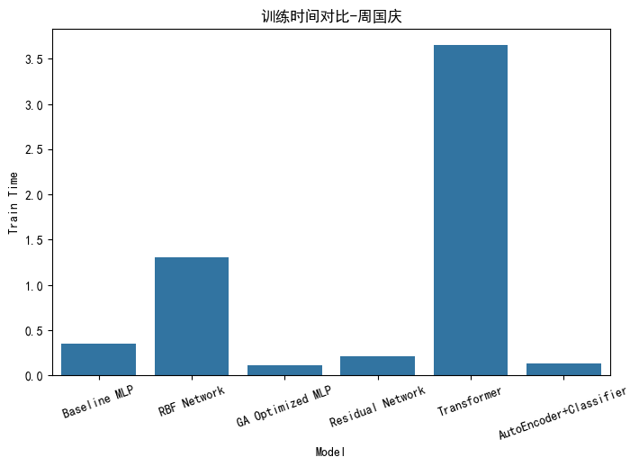

```python
plt.figure(figsize=(8,5))
sns.barplot(data=result_df, x="Model", y="Train Time")
plt.xticks(rotation=20)
plt.title("训练时间对比-周国庆")
plt.show()
```

### 综合结果分析

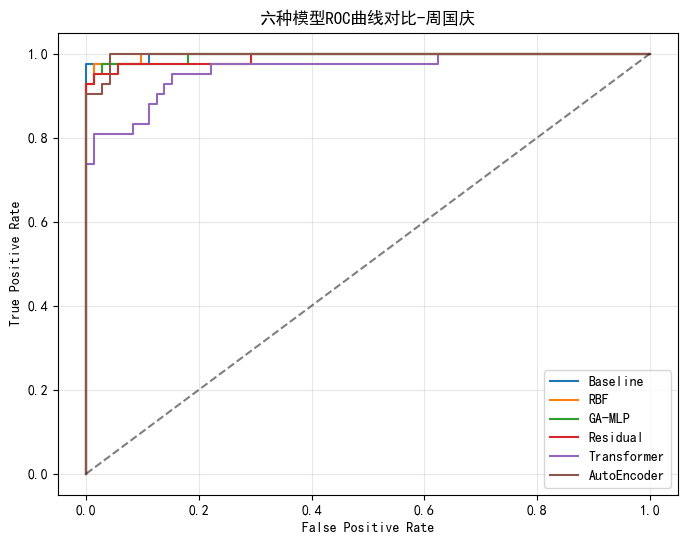

```python
plt.figure(figsize=(8,6))

for name, prob in [
    ("Baseline", prob_base), ("RBF", prob_rbf),
    ("GA-MLP", prob_ga), ("Residual", prob_res),
    ("Transformer", prob_trans), ("AutoEncoder", prob_ae)
]:
    fpr, tpr, _ = roc_curve(y_test, prob.cpu().numpy())
    plt.plot(fpr, tpr, label=name)

plt.plot([0,1], [0,1], 'k--', alpha=0.5)
plt.xlabel("False Positive Rate")
plt.ylabel("True Positive Rate")
plt.title("六种模型ROC曲线对比-周国庆")
plt.legend()
plt.grid(alpha=0.3)
plt.show()
```